# Practical Session: Periodicity

## Periodicity

```r
# Install pacman if not installed already, and activate it
rm(list=ls())

if (!require("pacman")) install.packages("pacman")

# Install, update and activate libraries
pacman::p_load(
  here,
  rio,
  skimr,
  tsibble,
  TSA,
  season,
  lmtest,
  MASS,
  gtsummary,
  tidyverse
)

# Create tsa_theme from previous exercise to be used in ggplot.
tsa_theme <- theme_bw() +
        theme(
            plot.title = element_text(face = "bold",
                                      size = 12),
            legend.background = element_rect(fill = "white",
                                             size = 4,
                                             colour = "white"),
            # legend.justification = c(0, 1),
            legend.position = "bottom",
            panel.grid.minor = element_blank()
        )
```

## Expected learning outcomes

By the end of this session, participants should be able to:

- identify and assess periodicity in surveillance data
- fit and interpret regression models containing a trend and one or more pairs of sine and cosine terms
- compare models with different sine and cosine terms

## Task 1

Using the mort_ts object (tibble), which is in `mort_ts.RData` (created in the Smoothing Practical), visually assess the existence of any periodicity in the total number of deaths (cyclical patterns).

What do you think the period is, if any? Discuss your results with your peers.

## Help for Task 1

```r
# Read data
load(here("data", "mort_ts.RData"))
```

*Explore the time series.*

Step 1)

The function decompose() decomposes the time series by applying moving averages to the series. It separates the time series into trend, seasonal and random components.

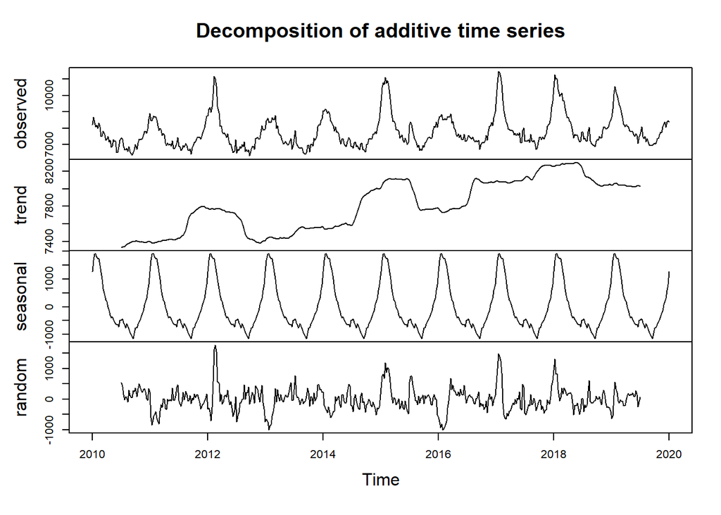

```r
# Convert the weekly data into a time series object
# Set the frequency to 52 observations per year
mort.ts  <- ts(mort_ts$cases, frequency=52, start=c(2010,1))

plot(decompose(mort.ts))
```

*Discuss the panels obtained. What features seem to be relevant?*

Step 2)

*Although we can see that there is a trend in the panels returned by decompose(), we wish to inspect it ourselves. Apply moving averages as in the Smoothing and Trends practical to explore if there is a trend. Which periodicity or periodicities might be relevant?*

Step 3)

*We will now estimate the trend, as was done in the Smoothing and Trends practical. Run the code in order to have at hand the results and be able to compare later with other models.

This model will serve as a reference when assessing whether adding periodic terms improves the model fit.*

```r
# Fit a Poisson regression model with a trend
mort_trend <- glm(cases ~ index, family = "poisson",
                  data = mort_ts)

summary(mort_trend)
```

```
Call:
glm(formula = cases ~ index, family = "poisson", data = mort_ts)

Coefficients:
             Estimate Std. Error z value Pr(>|z|)
(Intercept) 8.910e+00  1.007e-03 8850.25   <2e-16 ***
index       1.895e-04  3.302e-06   57.39   <2e-16 ***
---
Signif. codes:  0 '***' 0.001 '**' 0.01 '*' 0.05 '.' 0.1 ' ' 1

(Dispersion parameter for poisson family taken to be 1)

    Null deviance: 62509  on 520  degrees of freedom
Residual deviance: 59215  on 519  degrees of freedom
AIC: 64841

Number of Fisher Scoring iterations: 4
```

```r
mort_trend %>%
  gtsummary::tbl_regression(
    exponentiate = TRUE,
    estimate_fun = ~gtsummary::style_number(.x, digits = 6)
  ) %>%
  gtsummary::modify_header(estimate = "**Count ratio**") %>%
  gtsummary::modify_footnote(estimate = NA, abbreviation = TRUE)
```

| **Characteristic** | **Count ratio** | **95% CI** | **p-value** |
| --- | --- | --- | --- |
| index | 1.000189 | 1.000183, 1.000196 | <0.001 |

Abbreviations: CI = Confidence Interval, IRR = Incidence Rate Ratio, NA

*What is the direction and magnitude of the estimated weekly trend? Is it statistically significant?*

Step 4:

*As there seems to be some periodicity in the initial explorations, proceed to explore the periodic patterns in the time series.*

Seasonality and periodicity both refer to re-occurring patterns in the data.

A periodogram is a graph that shows the strength of periodic patterns at different frequencies. R has a number of functions which produce a periodogram. Here we will use the `periodogram` function from the `TSA` package.

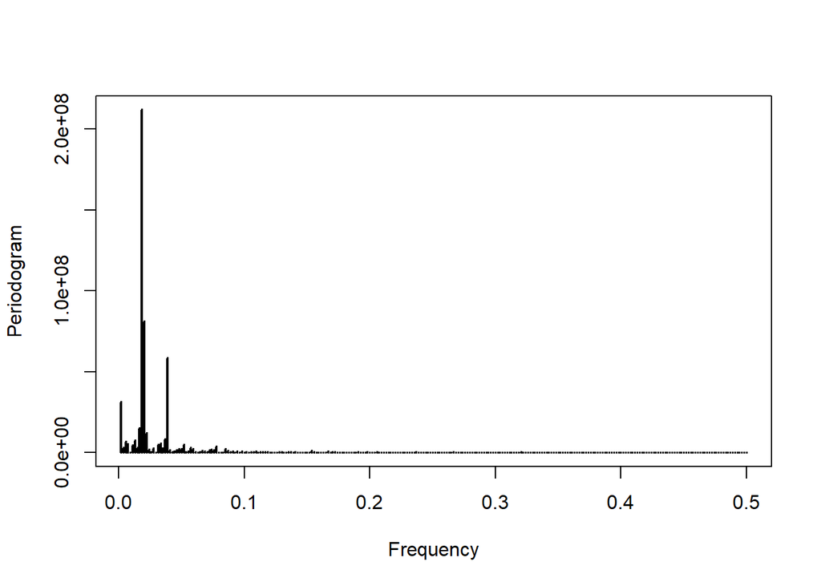

```r
mort_period <- TSA::periodogram(mort_ts$cases)
```

The `periodogram` function plots the estimated periodogram for a given time series and also returns various useful outputs as a list, which we can use for other analyses.

This type of plot is interpreted by identifying peaks. Higher peaks indicate stronger periodic patterns. To obtain something that can be easily interpretable, we will extract the spectra and frequencies from the output of the periodogram, and calculate the periods by taking the reciprocal of the frequencies, and then plot the periodogram against the periods.

```r
mort_period_recip <-
    tibble(
        freq = mort_period$freq,
        spec = mort_period$spec
    ) %>%
    arrange(desc(spec)) %>%
    mutate(reciprocal_freq = 1 / freq)  # period in weeks

view(mort_period_recip)

head(mort_period_recip, 10)
```

```
# A tibble: 10 × 3
      freq       spec reciprocal_freq
     <dbl>      <dbl>           <dbl>
 1 0.0185  212040398.            54
 2 0.0204   81190125.            49.1
 3 0.0389   58486015.            25.7
 4 0.00185  31364347.           540
 5 0.0167   15179045.            60
 6 0.0222   12238739.            45
 7 0.0370    8340641.            27
 8 0.0130    7642704.            77.1
 9 0.00556   6785699.           180
10 0.0333    5618933.            30
```

The above lines of code extract two variables (`freq` and `spec`) from the `mort_period` object and place them in a `tibble` data.frame. The rows are ordered in descending order of the spectral variable `spec`. At the top of the table we find the strongest spectral signal, as well as its corresponding period (see reciprocal frequency). Observe that the reciprocal frequency is in the same units as the data, in this case is in  
weeks.

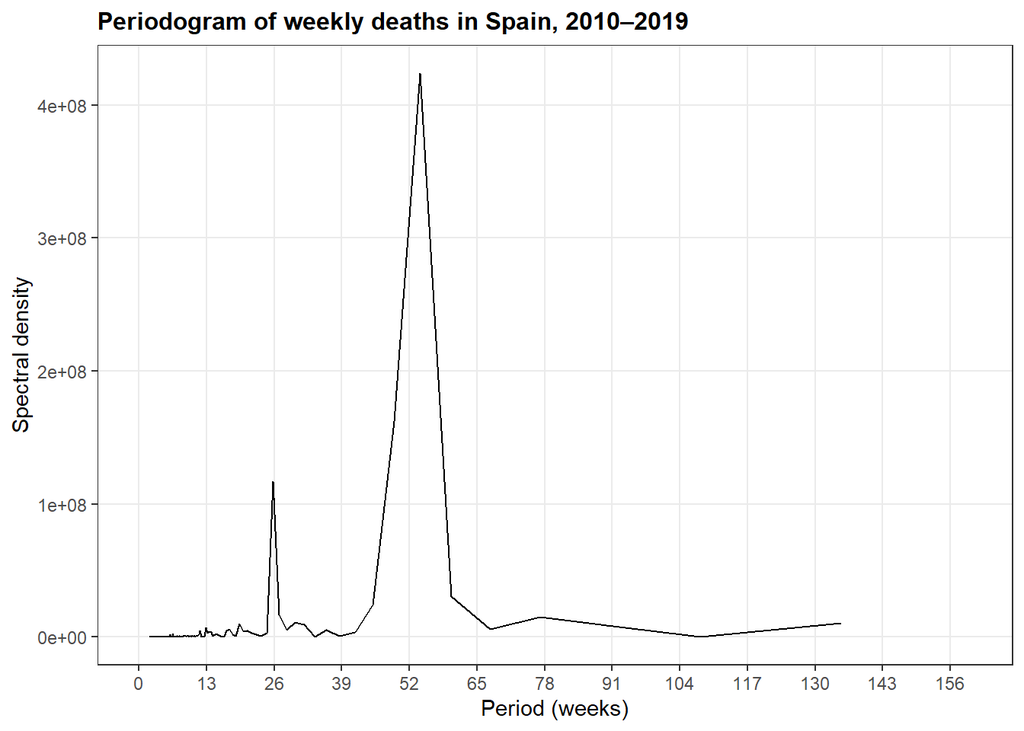

```r
# breaks every 13, equivalent to every 3 months approximately.

ggplot(data = mort_period_recip, aes(x = reciprocal_freq, y = 2*spec)) +
    geom_line() +
    scale_x_continuous(limits = c(0, 160), breaks=seq(0, 160, 13)) +
    labs(x = "Period (weeks)",
         y = "Spectral density",
         title = "Periodogram of weekly deaths in Spain, 2010–2019") +
    tsa_theme
```

*What is the main periodicity in the mortality data? (use the plot and the table of mort_period_recip).*

*Is there another periodicity that might be worth checking out?*

## Task 2

*Fit a model with a trend and add the relevant periodic terms.*

*How many different periods are you including in your model? Test statistically if the inclusion of more than one period improves the model fit. Discuss your results.*

As the periodogram shows periodicity close to 52 weeks, we will use a pair of sine and cosine terms with a period of 52 weeks. Periodicity with a period of one year is also referred to as seasonality.

Fit a Poisson regression of `cases` that contains a trend as well as a pair of sine and cosine terms for the identified period. In order to have an appropriate phase in your model (you do not have to worry about identifying it; this will happen automatically), you need to use both a sine and a cosine curve with the same period. By including both terms, the model can estimate the amplitude (strength of the seasonal variation) and phase (timing of the seasonal peak).

```r
# Calculate the sine and cosine terms for a 52-week period
mort_ts <- mort_ts %>%
  mutate(cos52 = cos(2 * pi * index / 52),
         sin52 = sin(2 * pi * index / 52))

mort_trendsin52cos52 <- glm(cases ~ index + sin52 + cos52, family = "poisson", data = mort_ts)

summary(mort_trendsin52cos52)
```

```
Call:
glm(formula = cases ~ index + sin52 + cos52, family = "poisson",
    data = mort_ts)

Coefficients:
             Estimate Std. Error z value Pr(>|z|)
(Intercept) 8.898e+00  1.012e-03 8792.82   <2e-16 ***
index       2.184e-04  3.311e-06   65.97   <2e-16 ***
sin52       9.137e-02  7.066e-04  129.29   <2e-16 ***
cos52       1.061e-01  7.033e-04  150.88   <2e-16 ***
---
Signif. codes:  0 '***' 0.001 '**' 0.01 '*' 0.05 '.' 0.1 ' ' 1

(Dispersion parameter for poisson family taken to be 1)

    Null deviance: 62509  on 520  degrees of freedom
Residual deviance: 19668  on 517  degrees of freedom
AIC: 25298

Number of Fisher Scoring iterations: 3
```

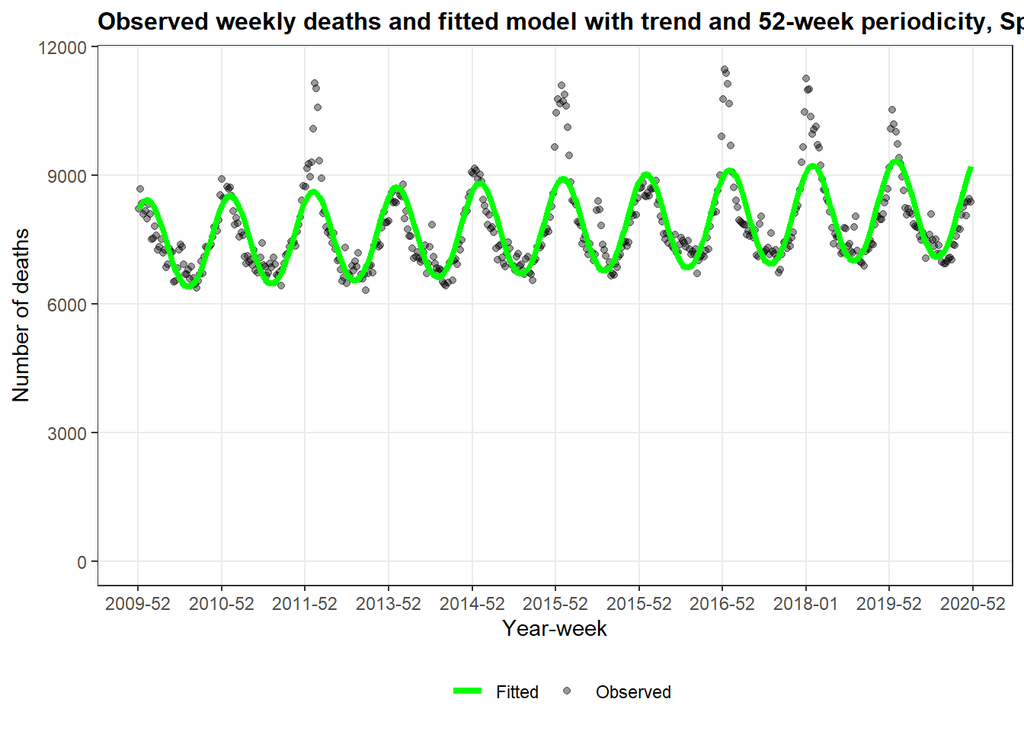

```r
colors <- c("Observed" = "black", "Fitted" = "green")

ggplot(data = mort_ts, aes(x = date_index)) +
    geom_point(aes(y = cases, colour = "Observed"), alpha = 0.4) +
    geom_line(
        mapping = aes(y = fitted(mort_trendsin52cos52),
                      colour = "Fitted"),
        linewidth = 1.5
    ) +
    scale_y_continuous(limits = c(0, NA)) +
    scale_x_yearweek(date_labels = "%Y-%W",
                     date_breaks = "1 year") +
    labs(x = "Year-week",
         y = "Number of deaths",
         title = "Observed weekly deaths and fitted model with trend and 52-week periodicity, Spain, 2010–2019") +
    scale_color_manual(values = colors, name = "") +
    tsa_theme
```

*How does the fit look visually?*

*Plot the results of the model with only trend and the model with trend and 52-week periodicity. Compare the models visually and statistically and comment on the results.*

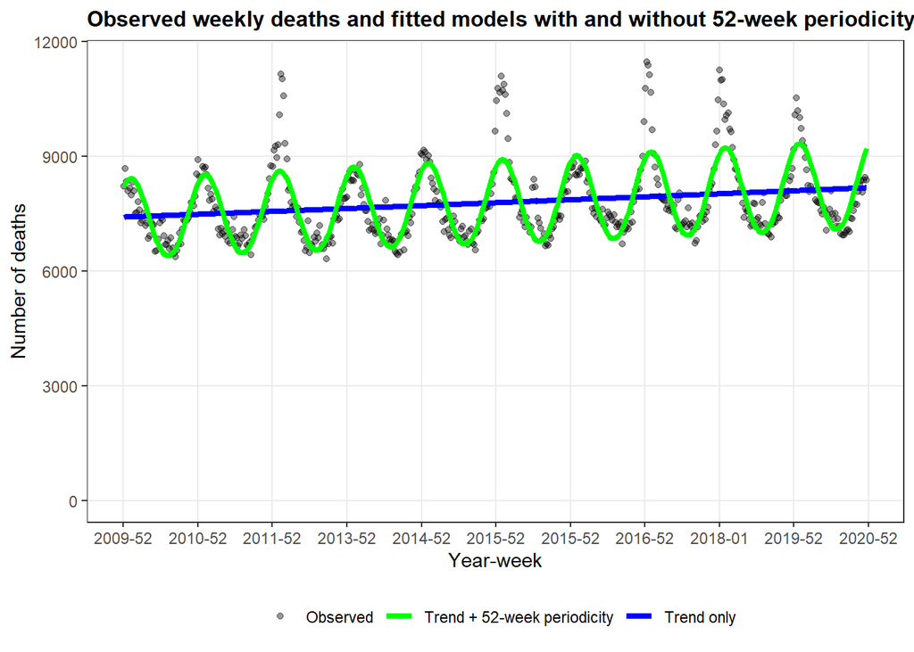

```r
colors <- c("Observed" = "black",
            "Trend only" = "blue",
            "Trend + 52-week periodicity" = "green")

ggplot(data = mort_ts, aes(x = date_index)) +
    geom_point(aes(y = cases, colour = "Observed"),
               alpha = 0.4) +
    geom_line(
        mapping = aes(y = fitted(mort_trend),
                      colour = "Trend only"),
        linewidth = 1.5
    ) +
    geom_line(
        mapping = aes(y = fitted(mort_trendsin52cos52),
                      colour = "Trend + 52-week periodicity"),
        linewidth = 1.5
    ) +
    scale_y_continuous(limits = c(0, NA)) +
    scale_x_yearweek(date_labels = "%Y-%W",
                     date_breaks = "1 year") +
    labs(x = "Year-week",
         y = "Number of deaths",
         title = "Observed weekly deaths and fitted models with and without 52-week periodicity, Spain, 2010–2019") +
    scale_color_manual(values = colors, name = "") +
    tsa_theme
```

To compare two nested models, we make use of the likelihood ratio test (LRT). These models are nested since the second model has the same variables as the first plus some additional ones.

For the comparison to be valid, both models must be fitted to the same data.

```r
# likelihood ratio test: compares two nested models

# test sin52 and cos52
lrtest(mort_trend, mort_trendsin52cos52)
```

```
Likelihood ratio test

Model 1: cases ~ index
Model 2: cases ~ index + sin52 + cos52
  #Df LogLik Df Chisq Pr(>Chisq)
1   2 -32418
2   4 -12645  2 39547  < 2.2e-16 ***
---
Signif. codes:  0 '***' 0.001 '**' 0.01 '*' 0.05 '.' 0.1 ' ' 1
```

A statistically significant result from the LRT, assuming the model assumptions hold, indicates that the extra variable(s) result in a better fit of the more complex model. In this case, a better fit to the data is obtained when we include the seasonality at 52 weeks.

To improve the model fit, we could try to add more sine/cosine terms, of a period corresponding to another prominent peak in the periodogram (approximately 26 weeks). This will allow for cycles (periods) of not only 52, but also 26 weeks, should we think there might be half-yearly cycles which are relevant.

Adding a 26-week period also allows the model to capture a more complex seasonal pattern.

In this case, for instance, there may be elevated mortality in winter, but also in summer during heatwaves.

Generate sine and cosine terms with a period of 26 weeks and name them `sin26` and `cos26`. Add these two new terms to the previous model.

```r
mort_period <-
    mort_ts %>%
    mutate(
        sin26 = sin(2 * pi * index / 26),
        cos26 = cos(2 * pi * index / 26)
    )

mort_trendsin2cos2 <- glm(cases ~ index + sin52 + cos52 + sin26 + cos26,
                           family = "poisson",
                           data = mort_period)

summary(mort_trendsin2cos2)
```

```
Call:
glm(formula = cases ~ index + sin52 + cos52 + sin26 + cos26,
    family = "poisson", data = mort_period)

Coefficients:
             Estimate Std. Error z value Pr(>|z|)
(Intercept) 8.895e+00  1.013e-03 8779.51   <2e-16 ***
index       2.265e-04  3.313e-06   68.35   <2e-16 ***
sin52       9.034e-02  7.142e-04  126.48   <2e-16 ***
cos52       1.021e-01  6.994e-04  145.94   <2e-16 ***
sin26       5.075e-02  7.054e-04   71.94   <2e-16 ***
cos26       3.298e-02  7.034e-04   46.88   <2e-16 ***
---
Signif. codes:  0 '***' 0.001 '**' 0.01 '*' 0.05 '.' 0.1 ' ' 1

(Dispersion parameter for poisson family taken to be 1)

    Null deviance: 62509  on 520  degrees of freedom
Residual deviance: 12288  on 515  degrees of freedom
AIC: 17922

Number of Fisher Scoring iterations: 3
```

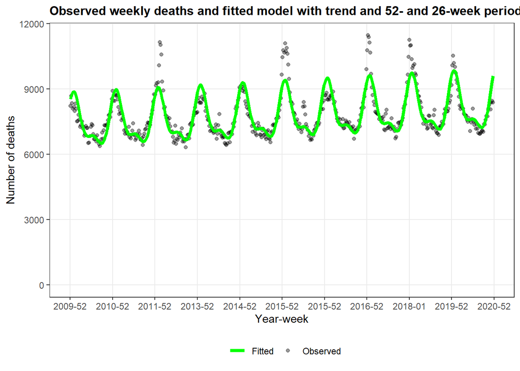

```r
colors <- c("Observed" = "black", "Fitted" = "green")

ggplot(data = mort_period, aes(x = date_index)) +
    geom_point(aes(y = cases, colour = "Observed"),
               alpha = 0.4) +
    geom_line(
        mapping = aes(y = fitted(mort_trendsin2cos2),
                      colour = "Fitted"),
        linewidth = 1.5
    ) +
    scale_y_continuous(limits = c(0, NA)) +
    scale_x_yearweek(date_labels = "%Y-%W",
                     date_breaks = "1 year") +
    labs(x = "Year-week",
         y = "Number of deaths",
         title = "Observed weekly deaths and fitted model with trend and 52- and 26-week periodicities, Spain, 2010–2019") +
    scale_color_manual(values = colors, name = "") +
    tsa_theme
```

*Test if the model with two periodicities fits better than the model with one.*

```r
# likelihood ratio test: compares two nested models

# test sin26 and cos26
lrtest(mort_trendsin52cos52, mort_trendsin2cos2)
```

```
Likelihood ratio test

Model 1: cases ~ index + sin52 + cos52
Model 2: cases ~ index + sin52 + cos52 + sin26 + cos26
  #Df   LogLik Df Chisq Pr(>Chisq)
1   4 -12644.9
2   6  -8954.9  2  7380  < 2.2e-16 ***
---
Signif. codes:  0 '***' 0.001 '**' 0.01 '*' 0.05 '.' 0.1 ' ' 1
```

*Is the addition of periodicity at 26 weeks a statistically significant contribution to your model?*

## Task 3

*Fit the final model using negative binomial regression. Plot the fitted values from the Poisson and negative binomial models. Which do you think fits best? Compare AIC for both models.*

The code for fitting a negative binomial regression model is very similar to that for Poisson regression. We use the `glm.nb()` function from the `MASS` package.

```r
mort_trendsin2cos2_nbin <- glm.nb(cases ~ index + sin52 + cos52 + sin26 + cos26,
                           data = mort_period)

summary(mort_trendsin2cos2_nbin)
```

```
Call:
glm.nb(formula = cases ~ index + sin52 + cos52 + sin26 + cos26,
    data = mort_period, init.theta = 382.8017317, link = log)

Coefficients:
             Estimate Std. Error z value Pr(>|z|)
(Intercept) 8.896e+00  4.611e-03 1929.28   <2e-16 ***
index       2.212e-04  1.531e-05   14.45   <2e-16 ***
sin52       8.955e-02  3.259e-03   27.48   <2e-16 ***
cos52       1.020e-01  3.240e-03   31.47   <2e-16 ***
sin26       4.909e-02  3.250e-03   15.11   <2e-16 ***
cos26       3.278e-02  3.242e-03   10.11   <2e-16 ***
---
Signif. codes:  0 '***' 0.001 '**' 0.01 '*' 0.05 '.' 0.1 ' ' 1

(Dispersion parameter for Negative Binomial(382.8017) family taken to be 1)

    Null deviance: 2812.16  on 520  degrees of freedom
Residual deviance:  518.74  on 515  degrees of freedom
AIC: 7746.1

Number of Fisher Scoring iterations: 1

              Theta:  382.8
          Std. Err.:  24.8

 2 x log-likelihood:  -7732.121
```

```r
aic_nbin <- AIC(mort_trendsin2cos2_nbin)
aic_nbin
```

```
[1] 7746.121
```

```r
aic_poi  <- AIC(mort_trendsin2cos2)
aic_poi
```

```
[1] 17921.74
```

When fitting a negative binomial model an additional parameter, theta is estimated to account for overdispersion. Smaller values of theta indicate greater overdispersion. As theta increases, the negative binomial distribution approaches the Poisson distribution.

AIC is the Akaike information criterion, a summary that can be used to compare different models, even when they are different types or are not nested.

Models should be fitted to the same outcome and observations.

The model with the lowest AIC is generally preferred.

*Which model is preferred according to AIC?*

Plot the fitted values from both models and compare them visually.

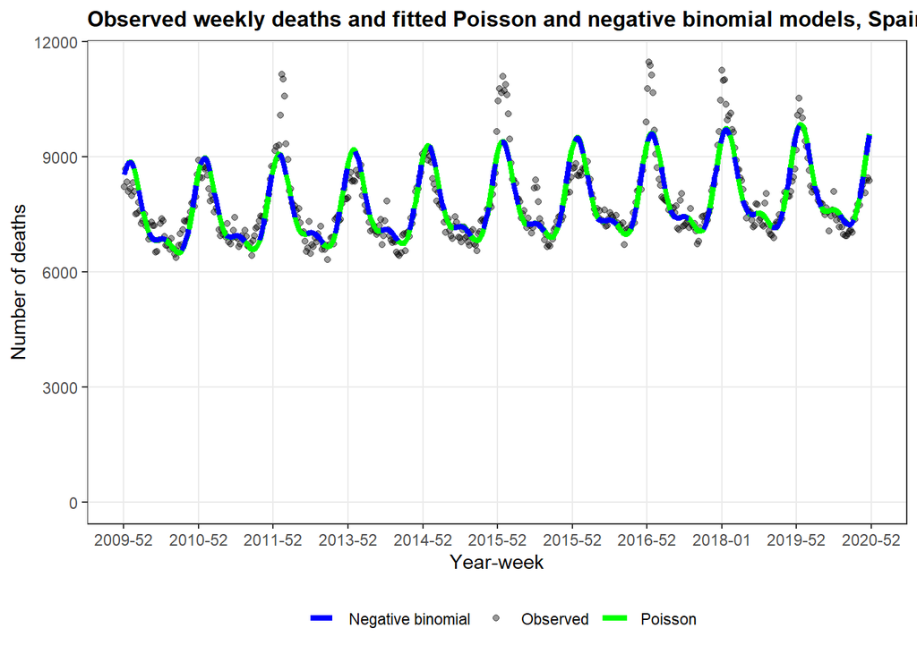

```r
colors <- c("Observed" = "black",
            "Poisson" = "green",
            "Negative binomial" = "blue")

ggplot(data = mort_period, aes(x = date_index)) +
    geom_point(aes(y = cases, colour = "Observed"),
               alpha = 0.4) +
    geom_line(
        aes(y = fitted(mort_trendsin2cos2),
            colour = "Poisson"),
        linewidth = 1.5
    ) +
    geom_line(
        aes(y = fitted(mort_trendsin2cos2_nbin),
            colour = "Negative binomial"),
        linewidth = 1.5,
        linetype = "dashed"
    ) +
    scale_y_continuous(limits = c(0, NA)) +
    scale_x_yearweek(date_labels = "%Y-%W",
                     date_breaks = "1 year") +
    labs(x = "Year-week",
         y = "Number of deaths",
         title = "Observed weekly deaths and fitted Poisson and negative binomial models, Spain, 2010–2019") +
    scale_color_manual(values = colors, name = "") +
    tsa_theme
```

*Are there noticeable differences between the fitted values from the two models?*

*Compare also the trends (as count ratios) and the coefficients of the different seasonal components.*

```r
# Estimates and 95% confidence intervals: negative binomial model
exp.nbin <- exp(cbind(
    Estimate = coef(mort_trendsin2cos2_nbin),
    confint(mort_trendsin2cos2_nbin)
))

# Width of the 95% confidence interval
exp.nbin <- cbind(exp.nbin,
    CI_width = exp.nbin[, "97.5 %"] - exp.nbin[, "2.5 %"])
exp.nbin
```

```
               Estimate       2.5 %      97.5 %     CI_width
(Intercept) 7304.396124 7238.629829 7370.872706 1.322429e+02
index          1.000221    1.000191    1.000251 6.016072e-05
sin52          1.093684    1.086726    1.100688 1.396251e-02
cos52          1.107350    1.100339    1.114406 1.406641e-02
sin26          1.050317    1.043664    1.057013 1.334899e-02
cos26          1.033318    1.026759    1.039919 1.315965e-02
```

```r
# Estimates and 95% confidence intervals: Poisson model
exp.poi <- exp(cbind(
    Estimate = coef(mort_trendsin2cos2),
    confint(mort_trendsin2cos2)
))

# Width of the 95% confidence interval
exp.poi <- cbind(exp.poi,
    CI_width = exp.poi[, "97.5 %"] - exp.poi[, "2.5 %"])
exp.poi
```

```
               Estimate       2.5 %      97.5 %     CI_width
(Intercept) 7294.022213 7279.549842 7308.517412 2.896757e+01
index          1.000226    1.000220    1.000233 1.298955e-05
sin52          1.094545    1.093014    1.096079 3.064442e-03
cos52          1.107465    1.105948    1.108985 3.036378e-03
sin26          1.052058    1.050604    1.053513 2.909134e-03
cos26          1.033528    1.032104    1.034954 2.849872e-03
```

*Are the estimates and confidence intervals similar between the fitted Poisson and the negative binomial models?*

## Task 4 (Optional)

*Carry out the same analysis for men and women. Do you see differences between the two? Are there differences in the trend or seasonal patterns?*

## Save

```r
# Save the mort_period data created during this case study to be used in the next practical.

# save(mort_period, mort_trendsin2cos2, file = here("data", "mort_period.RData"))
```